# A Philosophy Data Story

```r
library(dplyr)
library(ggplot2)
library(tm)
library(tidytext)
library(knitr)
library(sentimentr)
library(wordcloud)
```

## Section 1. Brief Information of Data

```r
phi_data <- read.csv('../../philosophy_data.csv')
head(phi_data)
```

|  | title | author | school | sentence_spacy | sentence_str | original_publication_date | corpus_edition_date | sentence_length | sentence_lowered | tokenized_txt | lemmatized_str |
| --- | --- | --- | --- | --- | --- | --- | --- | --- | --- | --- | --- |
| 1 | Plato - Complete Works | Plato | plato | What's new, Socrates, to make you leave your usual haunts in the Lyceum and spend your time here by the king archon's court? | What's new, Socrates, to make you leave your usual haunts in the Lyceum and spend your time here by the king archon's court? | -350 | 1997 | 125 | what's new, socrates, to make you leave your usual haunts in the lyceum and spend your time here by the king archon's court? | ['what', 'new', 'socrates', 'to', 'make', 'you', 'leave', 'your', 'usual', 'haunts', 'in', 'the', 'lyceum', 'and', 'spend', 'your', 'time', 'here', 'by', 'the', 'king', 'archon', 'court'] | what be new , Socrates , to make -PRON- leave -PRON- usual haunt in the Lyceum and spend -PRON- time here by the king archon 's court ? |
| 2 | Plato - Complete Works | Plato | plato | Surely you are not prosecuting anyone before the king archon as I am? | Surely you are not prosecuting anyone before the king archon as I am? | -350 | 1997 | 69 | surely you are not prosecuting anyone before the king archon as i am? | ['surely', 'you', 'are', 'not', 'prosecuting', 'anyone', 'before', 'the', 'king', 'archon', 'as', 'am'] | surely -PRON- be not prosecute anyone before the king archon as -PRON- be ? |
| 3 | Plato - Complete Works | Plato | plato | The Athenians do not call this a prosecution but an indictment, Euthyphro. | The Athenians do not call this a prosecution but an indictment, Euthyphro. | -350 | 1997 | 74 | the athenians do not call this a prosecution but an indictment, euthyphro. | ['the', 'athenians', 'do', 'not', 'call', 'this', 'prosecution', 'but', 'an', 'indictment', 'euthyphro'] | the Athenians do not call this a prosecution but an indictment , Euthyphro . |
| 4 | Plato - Complete Works | Plato | plato | What is this you say? | What is this you say? | -350 | 1997 | 21 | what is this you say? | ['what', 'is', 'this', 'you', 'say'] | what be this -PRON- say ? |
| 5 | Plato - Complete Works | Plato | plato | Someone must have indicted you, for you are not going to tell me that you have indicted someone else. | Someone must have indicted you, for you are not going to tell me that you have indicted someone else. | -350 | 1997 | 101 | someone must have indicted you, for you are not going to tell me that you have indicted someone else. | ['someone', 'must', 'have', 'indicted', 'you', 'for', 'you', 'are', 'not', 'going', 'to', 'tell', 'me', 'that', 'you', 'have', 'indicted', 'someone', 'else'] | someone must have indict -PRON- , for -PRON- be not go to tell -PRON- that -PRON- have indict someone else . |
| 6 | Plato - Complete Works | Plato | plato | But someone else has indicted you? | But someone else has indicted you? | -350 | 1997 | 34 | but someone else has indicted you? | ['but', 'someone', 'else', 'has', 'indicted', 'you'] | but someone else have indict -PRON- ? |

```r
colnames(phi_data)
```

```
 [1] "title"                     "author"                    "school"
 [4] "sentence_spacy"            "sentence_str"              "original_publication_date"
 [7] "corpus_edition_date"       "sentence_length"           "sentence_lowered"
[10] "tokenized_txt"             "lemmatized_str"
```

In this philosophy story, only columns *title*, *author*, *school*, *original_publication_date*, *sentence_length*, *sentence_lowered* and *lemmatized_str* are used.

A reordered dataset according to the original publication date is provided.

```r
new_phi_data <- phi_data[order(phi_data$original_publication_date),c("title", "author", "school", "original_publication_date", "sentence_length", "sentence_lowered", "lemmatized_str")]
```

## Section 2. Sentiment Analysis

In this part, sentiment score is used for sentence analysis.  
A score of **1** indicates positive sentiment, a score of **-1** indicates negative sentiment, and a score of **0** indicates neutral sentiment.  
The mean sentiment score of each book is calculated.

```r
list_title <- c()
list_sentimentscore <- c()
for (i in unique(new_phi_data$title)){
  list_title <- append(list_title, i)
  tem_df <- new_phi_data[new_phi_data$title == i,]
  tem_s <- sentiment(tem_df$sentence_lowered)
  sentiment_score <- mean(tem_s[tem_s$sentence_id==1,]$sentiment)
  list_sentimentscore <- append(list_sentimentscore, sentiment_score)
}
```

```r
# Create a new dataframe -title_score- for title and mean score.
title_score <- data.frame(list_title, list_sentimentscore)
colnames(title_score) <- c("title", "sentiment_score")
head(title_score)
```

|  | title | sentiment_score |
| --- | --- | --- |
| 1 | Plato - Complete Works | 0.07902373 |
| 2 | Aristotle - Complete Works | 0.04303201 |
| 3 | Enchiridion | 0.03897037 |
| 4 | Meditations | 0.08167870 |
| 5 | Discourse On Method | 0.18002976 |
| 6 | Meditations On First Philosophy | 0.06022149 |

```r
# Get unique values of (title, author, school, original_publication_date) in the new dataframe.
# Join the *title_score* and *unique_phi* together by column *title*.
unique_phi <- unique(new_phi_data[,c("title", "author", "school", "original_publication_date")])
phi_data_score <- merge(x=title_score, y=unique_phi, by="title")
head(phi_data_score)
```

|  | title | sentiment_score | author | school | original_publication_date |
| --- | --- | --- | --- | --- | --- |
| 1 | A General Theory Of Employment, Interest, And Money | 0.118110897 | Keynes | capitalism | 1936 |
| 2 | A Treatise Concerning The Principles Of Human Knowledge | 0.075660869 | Berkeley | empiricism | 1710 |
| 3 | A Treatise Of Human Nature | 0.100388201 | Hume | empiricism | 1739 |
| 4 | Anti-Oedipus | 0.000169128 | Deleuze | continental | 1972 |
| 5 | Aristotle - Complete Works | 0.043032008 | Aristotle | aristotle | -320 |
| 6 | Being And Time | 0.068765344 | Heidegger | phenomenology | 1927 |

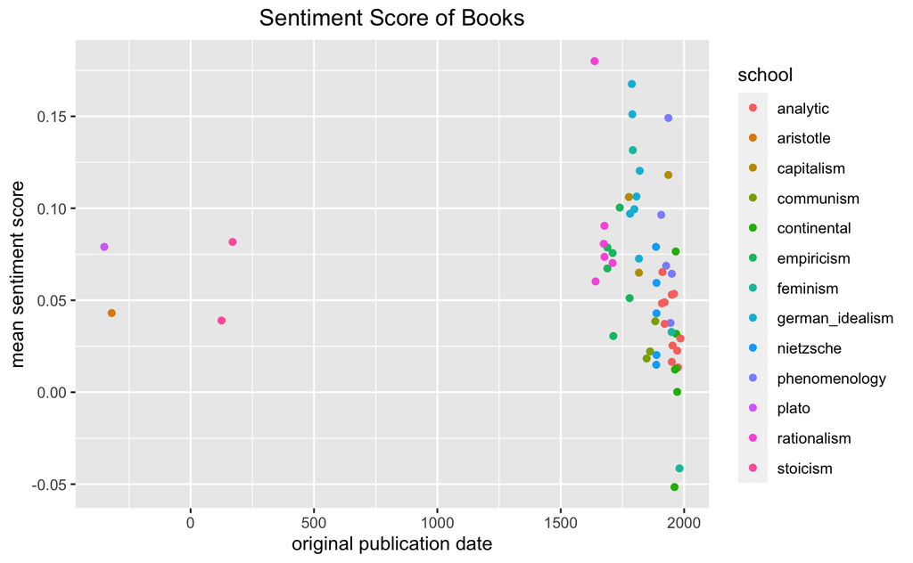

```r
# Plot sentiment score of books against their original publication date, also label their schools.
ggplot(data=phi_data_score)+
  geom_point(mapping=aes(x=original_publication_date, y=sentiment_score, color=school))+
  xlab("original publication date")+
  ylab("mean sentiment score")+
  ggtitle("Sentiment Score of Books")+
  theme(plot.title = element_text(hjust = 0.5))
```

From the graph, only 4 of the books were not published from 1500 to 2000.

```r
# Books with 2 lowest sentiment scores.
phi_data_score[order(phi_data_score$sentiment_score),][1:2,]$title
```

```
[1] "History Of Madness"     "Women, Race, And Class"
```

```r
# Book with highest sentiment score.
phi_data_score[order(phi_data_score$sentiment_score, decreasing = TRUE),][1,]$title
```

```
[1] "Discourse On Method"
```

We see that **History of Madness** and **Women, Race, And Class** have lowest sentiment scores and **Discourse On Method** has highest sentiment score.

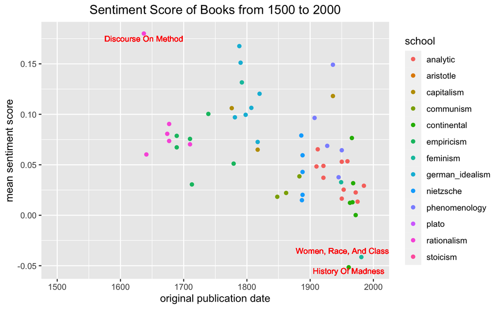

```r
# A closer look from 1500 to 2000.
ggplot(data=phi_data_score)+
  geom_point(mapping=aes(x=original_publication_date, y=sentiment_score, color=school))+
  xlab("original publication date")+
  ylab("mean sentiment score")+
  ggtitle("Sentiment Score of Books from 1500 to 2000")+
  xlim(c(1500,2000))+
  geom_text(x=1637,y=0.175, label="Discourse On Method", color="red", size=3)+
  geom_text(x=1961,y=-0.055, label="History Of Madness", color="red", size=3)+
  geom_text(x=1951,y=-0.035, label="Women, Race, And Class", color="red", size=3)+
  theme(plot.title = element_text(hjust = 0.5))
```

From the closer look, books of **german_idealism** are often with higher sentiment scores and books of **continental** are often with lower sentiment scores.  
These three books and two schools will be analyzed further.

## Section 3. Word Cloud Analysis

The text mining method of word cloud enables us to highlight the most frequently used keywords in the text.

### 3.1 History Of Madness

```r
# Load the text data as a Corpus.
hm <- phi_data%>%filter(title=="History Of Madness")
hm_lemma <- iconv(hm$lemmatized_str)
hm_lemma <- Corpus(VectorSource(hm_lemma))
```

```r
# Clean data: remove punctuation, some words, numbers, stop words and white space.
hm_lemma <- hm_lemma%>%
  tm_map(removePunctuation)%>%
  tm_map(removeWords, c("PRON", "one", "can", "must", "also", "may"))%>%
  tm_map(removeNumbers)%>%
  tm_map(removeWords, stopwords("english"))%>%
  tm_map(stripWhitespace)
```

```r
# Construct a document matrix - a table containing the frequency of words.
hm_dtm <- TermDocumentMatrix(hm_lemma)
hm_tidy <- tidy(hm_dtm)
hm_overall <- summarise(group_by(hm_tidy, term), sum(count))
```

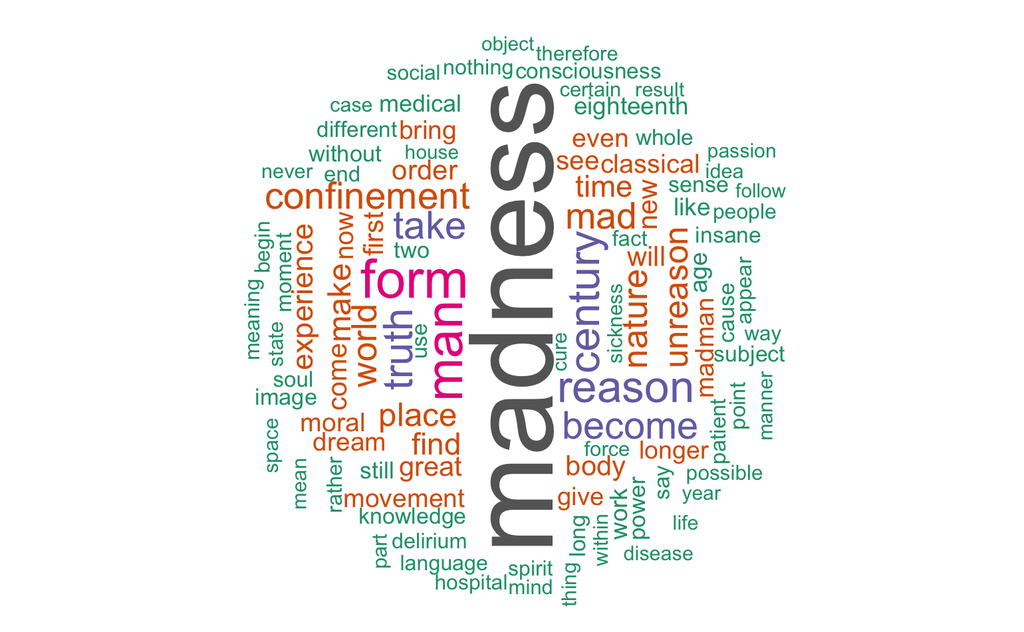

```r
wordcloud(hm_overall$term, hm_overall$`sum(count)`,
          scale=c(5,0.5),
          max.words=100,
          min.freq=1,
          random.order=FALSE,
          rot.per=0.3,
          random.color=FALSE,
          colors=brewer.pal(9,"Dark2"))
```

The book **History of Madness** talks about the origin and earlier development of madness. From the word cloud graph above, words like **confinement, madness, insane, madman, delirium** refer how people with madness are treated. Most of the words here are negative, which is in line with the sentiment score of the book.

### 3.2 Women, Race, And Class

```r
wrc <- phi_data%>%filter(title=="Women, Race, And Class")
wrc_lemma <- iconv(wrc$lemmatized_str)
wrc_lemma <- Corpus(VectorSource(wrc_lemma))
```

```r
wrc_lemma <- wrc_lemma%>%
  tm_map(removePunctuation)%>%
  tm_map(removeWords, c("PRON", "one", "can", "must", "also", "may"))%>%
  tm_map(removeNumbers)%>%
  tm_map(removeWords, stopwords("english"))%>%
  tm_map(stripWhitespace)
```

```r
wrc_dtm <- TermDocumentMatrix(wrc_lemma)
wrc_tidy <- tidy(wrc_dtm)
wrc_overall <- summarise(group_by(wrc_tidy, term), sum(count))
```

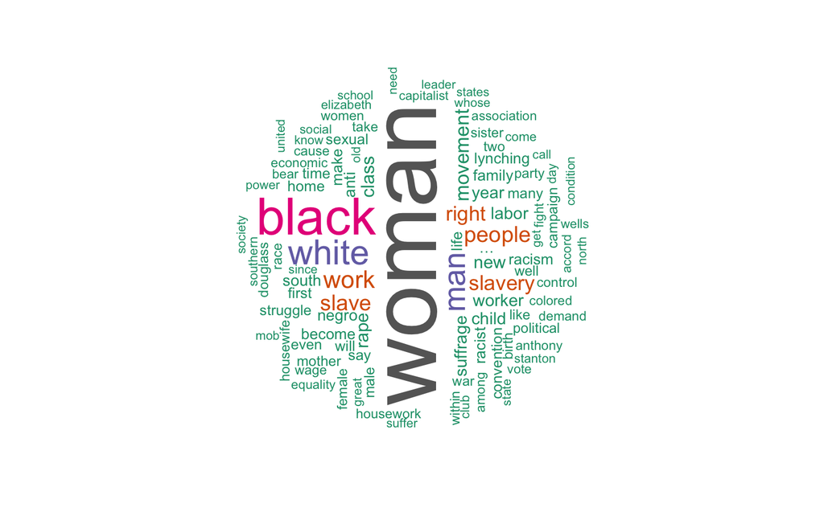

```r
wordcloud(wrc_overall$term, wrc_overall$`sum(count)`,
          scale=c(5,0.5),
          max.words=100,
          min.freq=1,
          random.order=FALSE,
          rot.per=0.3,
          random.color=FALSE,
          colors=brewer.pal(9,"Dark2"))
```

The book **Women, Race, And Class** contains Marxist feminist analysis of gender, race and class. Words like **woman, man, sexual** imply that this book talks mainly about genders. Also, based on genders, topics about races(black, white) are also discussed. This book also talks about slavery and the potential economic effect it has.

### 3.3 Discourse On Method

```r
dm <- phi_data%>%filter(title=="Discourse On Method")
dm_lemma <- iconv(dm$lemmatized_str)
dm_lemma <- Corpus(VectorSource(dm_lemma))
```

```r
dm_lemma <- dm_lemma%>%
  tm_map(removePunctuation)%>%
  tm_map(removeWords, c("PRON", "one", "can", "must", "also", "may"))%>%
  tm_map(removeNumbers)%>%
  tm_map(removeWords, stopwords("english"))%>%
  tm_map(stripWhitespace)
```

```r
dm_dtm <- TermDocumentMatrix(dm_lemma)
dm_tidy <- tidy(dm_dtm)
dm_overall <- summarise(group_by(dm_tidy, term), sum(count))
```

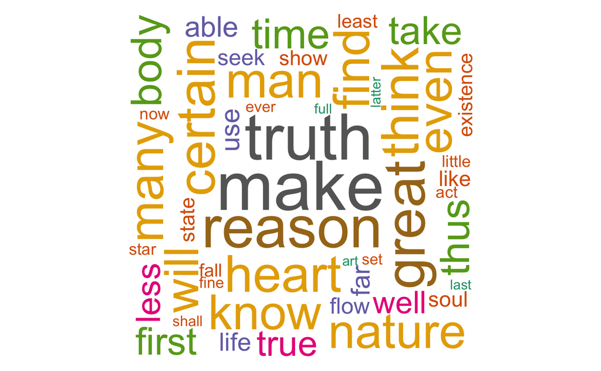

```r
wordcloud(dm_overall$term, dm_overall$`sum(count)`,
          scale=c(5,0.5),
          max.words=300,
          min.freq=1,
          random.order=FALSE,
          rot.per=0.3,
          random.color=FALSE,
          colors=brewer.pal(9,"Dark2"))
```

The book **Discourse On Method**, from school of rationalism, is important to the development of natural sciences. The book aims to talk about four methods to solve problems in nature. From the word cloud graph above, words like **nature, truth, reason** also point out the main ideas.

### 3.4 School of german_idealism

Books from school of german_idealism are with higher sentiment scores.

```r
germ <- phi_data%>%filter(school=="german_idealism")
germ_lemma <- iconv(germ$lemmatized_str)
germ_lemma <- Corpus(VectorSource(germ_lemma))
```

```r
germ_lemma <- germ_lemma%>%
  tm_map(removePunctuation)%>%
  tm_map(removeWords, c("PRON", "one", "can", "must", "also", "may"))%>%
  tm_map(removeNumbers)%>%
  tm_map(removeWords, stopwords("english"))%>%
  tm_map(stripWhitespace)
```

```r
germ_dtm <- TermDocumentMatrix(germ_lemma)
germ_tidy <- tidy(germ_dtm)
germ_overall <- summarise(group_by(germ_tidy, term), sum(count))
```

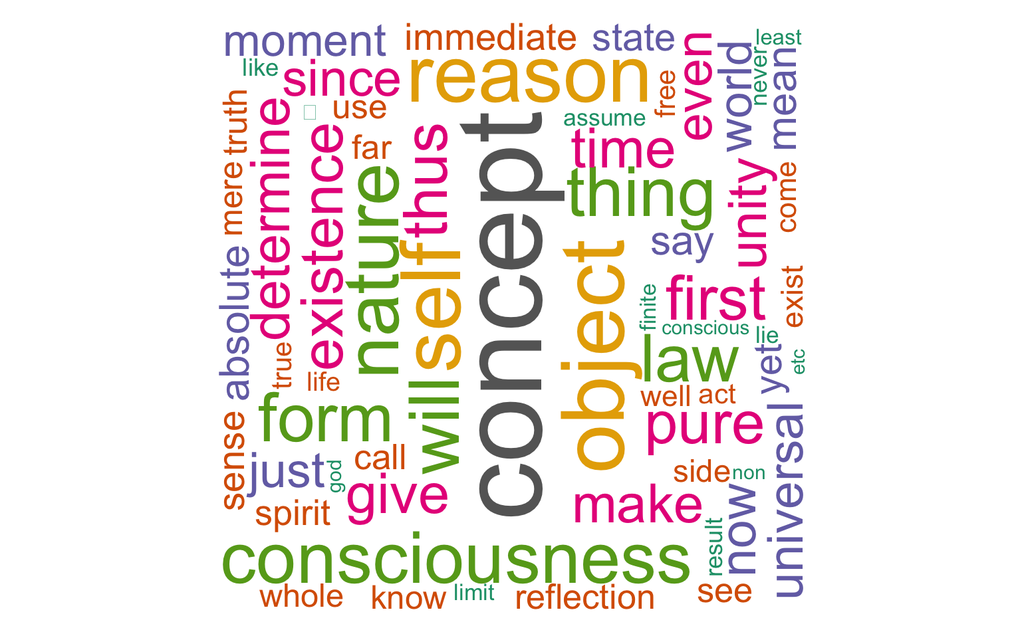

```r
wordcloud(germ_overall$term, germ_overall$`sum(count)`,
          scale=c(5,0.5),
          max.words=300,
          min.freq=1,
          random.order=FALSE,
          rot.per=0.3,
          random.color=FALSE,
          colors=brewer.pal(9,"Dark2"))
```

The philosophical meaning of idealism are those properties we discover in objects are dependent on the way that those objects appear to us, as perceiving subjects.  
From the word cloud graph above, words like **concept, self** also illustrate this.

### 3.5 School of continental

Books from school of continental are with lower sentiment scores.

```r
cont_sch <- phi_data%>%filter(school=="continental")
cont_sch_lemma <- iconv(cont_sch$lemmatized_str)
cont_sch_lemma <- Corpus(VectorSource(cont_sch_lemma))
```

```r
cont_sch_lemma <- cont_sch_lemma%>%
  tm_map(removePunctuation)%>%
  tm_map(removeWords, c("PRON", "one", "can", "must", "also", "may"))%>%
  tm_map(removeNumbers)%>%
  tm_map(removeWords, stopwords("english"))%>%
  tm_map(stripWhitespace)
```

```r
cont_sch_dtm <- TermDocumentMatrix(cont_sch_lemma)
cont_sch_tidy <- tidy(cont_sch_dtm)
cont_sch_overall <- summarise(group_by(cont_sch_tidy, term), sum(count))
```

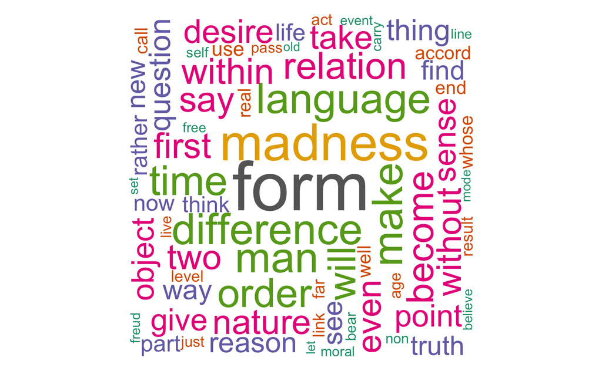

```r
wordcloud(cont_sch_overall$term, cont_sch_overall$`sum(count)`,
          scale=c(5,0.5),
          max.words=300,
          min.freq=1,
          random.order=FALSE,
          rot.per=0.3,
          random.color=FALSE,
          colors=brewer.pal(9,"Dark2"))
```

## Section 4. Sentence length Analysis

In this section, sentence length is more focused on.

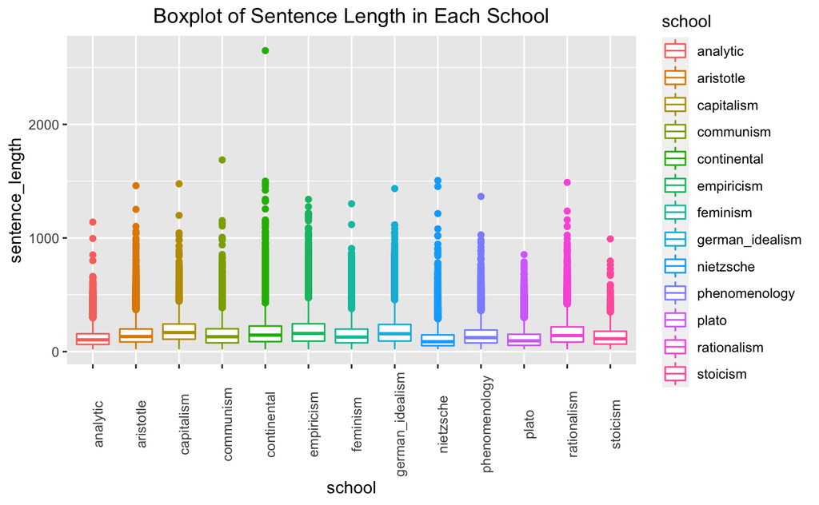

```r
ggplot(data=new_phi_data)+
  geom_boxplot(mapping=aes(x=school, y=sentence_length, color=school))+
  theme(axis.text.x=element_text(angle=90))+
  ggtitle("Boxplot of Sentence Length in Each School")+
  theme(plot.title = element_text(hjust = 0.5))
```

There are always outliers of sentence length in each school.

```r
# Calculate mean sentence of each book and combine it with phi_data_score.
title_length <-
  new_phi_data %>%
  group_by(title)%>%
  summarise(mean_sent_length=mean(sentence_length))
phi_data_score_length <- merge(phi_data_score, title_length, by="title")
```

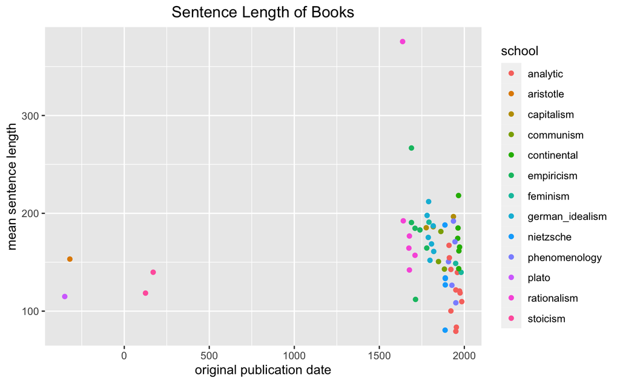

```r
ggplot(data=phi_data_score_length)+
  geom_point(mapping=aes(x=original_publication_date, y=mean_sent_length, color=school))+
  xlab("original publication date")+
  ylab("mean sentence length")+
  ggtitle("Sentence Length of Books")+
  theme(plot.title = element_text(hjust = 0.5))
```

The mean sentence length of books from the same school tends to be together.

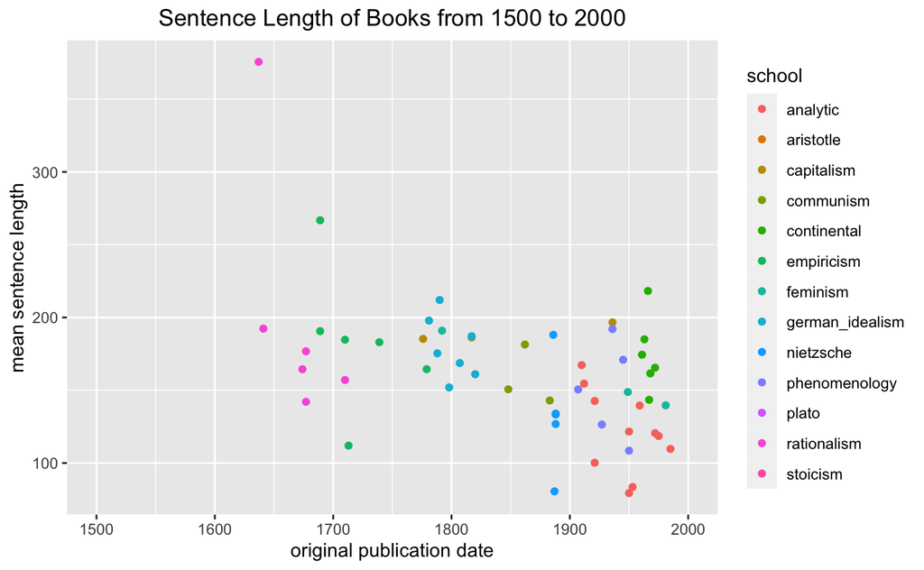

```r
ggplot(data=phi_data_score_length)+
  geom_point(mapping=aes(x=original_publication_date, y=mean_sent_length, color=school))+
  xlab("original publication date")+
  ylab("mean sentence length")+
  ggtitle("Sentence Length of Books from 1500 to 2000")+
  xlim(c(1500, 2000))+
  theme(plot.title = element_text(hjust = 0.5))
```

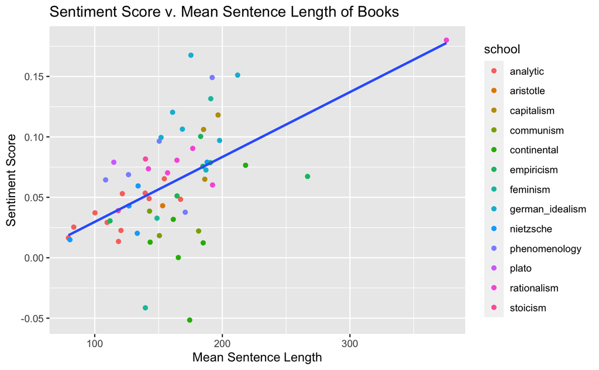

```r
ggplot(data=phi_data_score_length, mapping = aes(x=mean_sent_length, y=sentiment_score))+
  geom_point(mapping=aes(color=school))+
  geom_smooth(method="lm", se=FALSE)+
  xlab("Mean Sentence Length")+
  ylab("Sentiment Score")+
  ggtitle("Sentiment Score v. Mean Sentence Length of Books")
```

From the linear regression line in the graph, there seems to be a positive relation.

```r
lm <- lm(sentiment_score~mean_sent_length, data=phi_data_score_length)
summary(lm)
```

```
Call:
lm(formula = sentiment_score ~ mean_sent_length, data = phi_data_score_length)

Residuals:
      Min        1Q    Median        3Q       Max
-0.121187 -0.017792  0.000347  0.023102  0.097420

Coefficients:
                   Estimate Std. Error t value Pr(>|t|)
(Intercept)      -0.0240168  0.0182549  -1.316    0.194
mean_sent_length  0.0005369  0.0001101   4.877    9e-06 ***
---
Signif. codes:  0 ‘***’ 0.001 ‘**’ 0.01 ‘*’ 0.05 ‘.’ 0.1 ‘ ’ 1

Residual standard error: 0.03838 on 57 degrees of freedom
Multiple R-squared:  0.2945,    Adjusted R-squared:  0.2821
F-statistic: 23.79 on 1 and 57 DF,  p-value: 9e-06
```

The result of linear regression shows that there is a significant positive relation between sentiment score and mean sentence length, which means, book with longer sentences tends to be more positive.